# Homework 1

## Problem 5: Use the `flights` and `planes` tables to answer the following questions:

```
-   How many planes have a missing date of manufacture?
-   What are the five most common manufacturers?
-   Has the distribution of manufacturer changed over time as reflected by the airplanes flying from NYC in 2013? (Hint: you may need to use case_when() to recode the manufacturer name and collapse rare vendors into a category called Other.)
```

```r
# Filter all planes where year of manufacture is NA
missing_manu_plane <- filter(planes, is.na(year))
nrow(missing_manu_plane) #70 planes have no manufacture date
```

```
## [1] 70
```

```r
# Group the planes data frame by manufacturer and count the occurrences
manufacturer_counts <- planes %>%
  # Replace AIRBUS INDUSTRIE with AIRBUS as these refer to the same company
  mutate(manufacturer = recode(manufacturer,
                        "AIRBUS INDUSTRIE" = "AIRBUS",
                        "MCDONNELL DOUGLAS AIRCRAFT CO" = "MCDONNELL DOUGLAS",
                        "MCDONNELL DOUGLAS CORPORATION" = "MCDONNELL DOUGLAS"
                        )) %>%
  group_by(manufacturer) %>%
  summarise(count = n()) %>%
  arrange(desc(count))

# Select the top five manufacturers by count
top_manufacturers <- top_n(manufacturer_counts, n = 5, wt = count)
print(top_manufacturers) #BOEING, AIRBUS, BOMBARDIER INC, EMBRAER,MCDONNELL DOUGLAS
```

```
## # A tibble: 5 × 2
##   manufacturer      count
##   <chr>             <int>
## 1 BOEING             1630
## 2 AIRBUS              736
## 3 BOMBARDIER INC      368
## 4 EMBRAER             299
## 5 MCDONNELL DOUGLAS   237
```

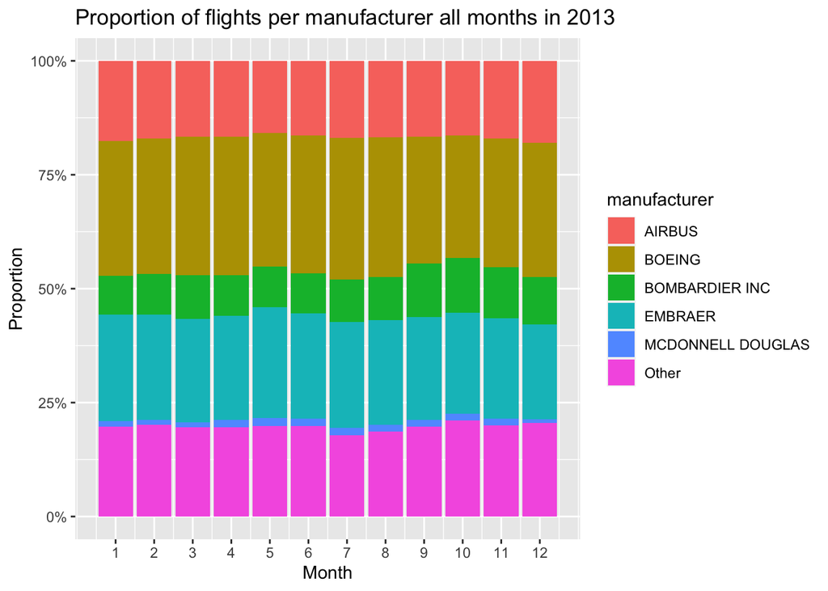

```r
# Get top manufacturer as a list
top_manufacturer_vector <- top_manufacturers$manufacturer

# Get all flights that werent cancelled
# Get only month, flight_no and tailnum
not_na_flights <- flights %>%
  filter(!is.na(dep_time)) %>%
  select (month, flight, tailnum)

# Left join unclassed flights with all planes data
# Join by tail number, filter out manufacturers that are NA
flights_with_manufacturer <- left_join(not_na_flights,
                                       planes %>%
                                         select (tailnum, manufacturer), by = "tailnum") %>%
  filter(!is.na(manufacturer))

# Mutate the manufacture column to be Other when not present
# in the list of top 5 manufacuters
# Group by month (in 2013) and manufacturer, count n in each group
collapsed_flights <- flights_with_manufacturer %>%
  mutate(manufacturer = case_when(
    manufacturer %in% top_manufacturer_vector ~ as.character(manufacturer),
    TRUE ~ "Other"
  )) %>%
  group_by(month, manufacturer) %>%
  summarise(count = n())

# Calculate the total number of uncancelled flights per month
flights_per_month <- flights_with_manufacturer %>%
  group_by(month) %>%
  summarise(total_flights_month = n())

# Join the two, divide flights per manufacturer by total flights
# This gives us percentage og flights per month per manufacturer
flights_by_manufacuter <- left_join(collapsed_flights,
                                    flights_per_month, by = "month") %>%
  mutate(manufacturer_percentage = count/total_flights_month)

# Create an stacked column chart
stacked_column_manufacturer_prop <-  ggplot(flights_by_manufacuter, aes(x = month, y = manufacturer_percentage, fill = manufacturer)) +
  geom_bar(stat = "identity") +
  labs(title = "Proportion of flights per manufacturer all months in 2013", x = "Month", y = "Proportion") +
  scale_x_continuous(breaks = seq(1,12, by = 1)) + #scale x axis as months 1-12
  scale_y_continuous(labels = scales::percent)  # Format y-axis labels as percentages

plot(stacked_column_manufacturer_prop)
```

## Problem 6: Use the `flights` and `planes` tables to answer the following questions:

```
-   What is the oldest plane (specified by the tailnum variable) that flew from New York City airports in 2013?
-   How many airplanes that flew from New York City are included in the planes table?
```

```r
#Assuming that only JFK and LaGuardia qualify as new york airports

# Get all planes that have taken off from NYC in 2013
planes_from_nyc_2013 <- flights %>%
  # Filter out cancelled flghts
  filter(!is.na(dep_time) & year == 2013) %>%
  # Filter NYC Takeoffs
  filter(origin  %in% c("JFK", "LGA")) %>%
  # Drop duplicate tailnum
  distinct(tailnum) %>%
  # Select only tailnum column
  pull(tailnum)

# Get oldest planes
oldest_planes <- planes %>%
  # Filter only planes that took off from nyc in 2013
  # and where there exists a manufacture date
  filter(tailnum %in% planes_from_nyc_2013 & !is.na(year)) %>%
  # Give me only ones with the lowest year
  top_n(n = 1, wt = -year) %>%
  # Select only tailnum, manufacturer and year column
  select(tailnum, manufacturer, year)

print(oldest_planes) # N381AA   DOUGLAS 1956
```

```
## # A tibble: 1 × 3
##   tailnum manufacturer  year
##   <chr>   <chr>        <int>
## 1 N381AA  DOUGLAS       1956
```

```r
# How many planes that flew from NYC in 2013 are in planes table
num_planes_nyc_2013 <- planes %>%
  # Filter only planes that took off from nyc in 2013
  filter(tailnum %in% planes_from_nyc_2013) %>%
  summarise(count = n())

print(num_planes_nyc_2013) # 2880 Planes in planes db, flew from NYC
```

```
## # A tibble: 1 × 1
##   count
##   <int>
## 1  2880
```

## Problem 7: Use the `nycflights13` to answer the following questions:

```
-   What is the median arrival delay on a month-by-month basis in each airport?
-   For each airline, plot the median arrival delay for each month and origin airport.
```

```r
# Median Arrival Delay
med_arr_delay_by_mon <- flights %>%
  # Filter out cancelled flights
  filter(!is.na(dep_time) & year == 2013) %>%
  # Group by destinato airport and month
  group_by(dest, month) %>%
  # Calculate median arr_delay
  summarise(med_arr_delay = median(arr_delay, na.rm=TRUE)) %>%
  # Pivot table to make month in columns
  pivot_wider(names_from = month, values_from = med_arr_delay)

print(med_arr_delay_by_mon)
```

```
## # A tibble: 104 × 13
## # Groups:   dest [104]
##    dest    `4`   `5`   `6`   `7`   `8`   `9`  `10`  `11`  `12`   `1`   `2`   `3`
##    <chr> <dbl> <dbl> <dbl> <dbl> <dbl> <dbl> <dbl> <dbl> <dbl> <dbl> <dbl> <dbl>
##  1 ABQ    14     -19  -2.5  -6   -14     -16 -10    -6    27    NA      NA  NA
##  2 ACK    NA      -8  -2     0.5  -6      -4  -1    NA    NA    NA      NA  NA
##  3 ALB     9       0 -14   -13   -19     -19  13    -1     0     6      -3   0.5
##  4 ANC    NA      NA  NA     1.5   3      NA  NA    NA    NA    NA      NA  NA
##  5 ATL     2      -4   3     7     1      -6  -4    -1     3    -2      -1  -4
##  6 AUS    -1.5    -9  -5.5   1    -5.5   -21  -9   -11     5    -2       2  -4
##  7 AVL   -22     -10  -2     2.5  -2      -3   7     2.5  -2    23.5    NA  NA
##  8 BDL    -3     -11  -2    49   -14     -17 -11     8     5.5 -10     -11  -1
##  9 BGR    12     -21  -7    11    25     -12 -12.5  -9.5  -3    NA      NA -22
## 10 BHM    -3     -23  11    21.5  -3     -17   4.5   5    31   -11     -10  -1
## # ℹ 94 more rows
```

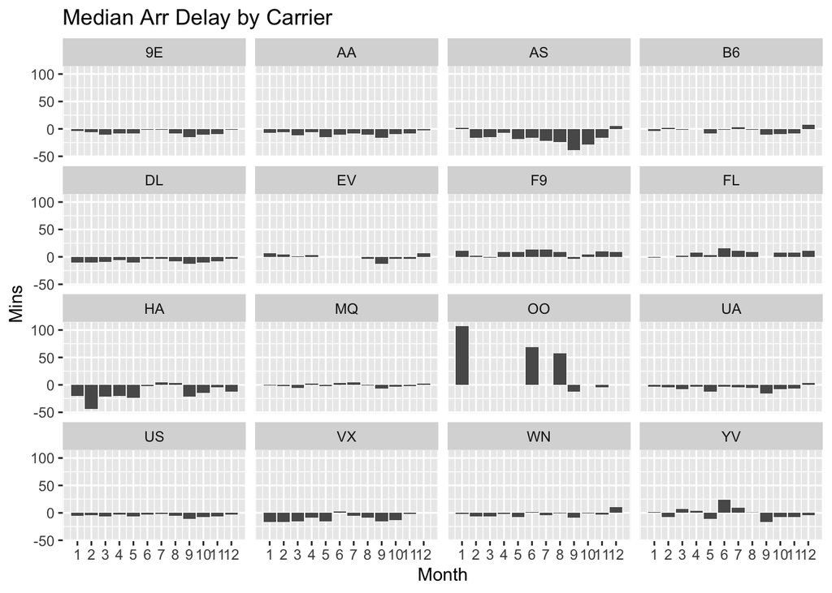

```r
med_arr_delay_by_carrier_mon <- flights %>%
  filter(!is.na(dep_time) & year == 2013) %>%
  group_by(carrier, month) %>%
  summarise(med_arr_delay = median(arr_delay, na.rm=TRUE))

plot_med_arr_delay_carrier_mon <- ggplot(med_arr_delay_by_carrier_mon,
                   aes(x = month, y = med_arr_delay)) +
  geom_bar(stat = "identity") +
  facet_wrap(. ~ carrier) +
  scale_x_continuous(breaks = seq(1,12, by = 1)) + #scale x axis as months 1-12
  labs(title = "Median Arr Delay by Carrier", x = "Month", y = "Mins")

plot(plot_med_arr_delay_carrier_mon)
```

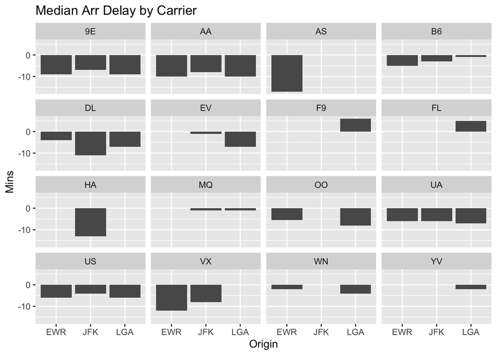

```r
med_arr_delay_by_carrier_origin <- flights %>%
  filter(!is.na(dep_time) & year == 2013) %>%
  group_by(carrier, origin) %>%
  summarise(med_arr_delay = median(arr_delay, na.rm=TRUE))

plot_med_arr_delay_carrier_origin <- ggplot(med_arr_delay_by_carrier_origin,
                   aes(x = origin, y = med_arr_delay)) +
  geom_bar(stat = "identity") +
  facet_wrap(. ~ carrier) +
  labs(title = "Median Arr Delay by Carrier", x = "Origin", y = "Mins")

plot(plot_med_arr_delay_carrier_origin)
```

## Problem 8: Let’s take a closer look at what carriers service the route to San Francisco International (SFO). Join the `flights` and `airlines` tables and count which airlines flew the most to SFO. Produce a new dataframe, `fly_into_sfo` that contains three variables: the `name` of the airline, e.g., `United Air Lines Inc.` not `UA`, the count (number) of times it flew to SFO, and the `percent` of the trips that that particular airline flew to SFO.

```r
# Join flights and airlines tables
total_flights_by_carriers <- flights %>%
  left_join(airlines, by = "carrier") %>%
  group_by(name) %>%
  summarise(total_flights = n())

# Join flights and airlines tables
fly_into_sfo <- flights %>%
  left_join(airlines, by = "carrier") %>%
  filter(dest == "SFO") %>%
  group_by(name) %>%
  summarise(count = n()) %>%
  left_join(total_flights_by_carriers, by = "name") %>%
  mutate(percent = count/total_flights) %>%
  select(name, count, percent) %>%
  arrange(desc(percent))
```

And here is some bonus ggplot code to plot your dataframe

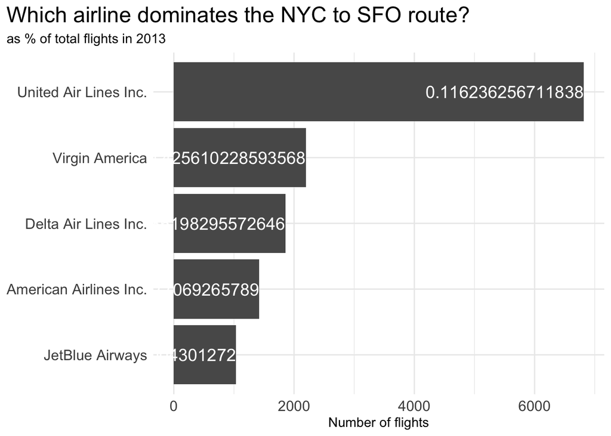

```r
    #| label: ggplot-flights-toSFO
    #| message: false
    #| warning: false

    fly_into_sfo %>%

      # sort 'name' of airline by the numbers it times to flew to SFO
      mutate(name = fct_reorder(name, count)) %>%

      ggplot() +

      aes(x = count,
          y = name) +

      # a simple bar/column plot
      geom_col() +

      # add labels, so each bar shows the % of total flights
      geom_text(aes(label = percent),
                 hjust = 1,
                 colour = "white",
                 size = 5)+

      # add labels to help our audience
      labs(title="Which airline dominates the NYC to SFO route?",
           subtitle = "as % of total flights in 2013",
           x= "Number of flights",
           y= NULL) +

      theme_minimal() +

      # change the theme-- i just googled those , but you can use the ggThemeAssist add-in
      # https://cran.r-project.org/web/packages/ggThemeAssist/index.html

      theme(#
        # so title is left-aligned
        plot.title.position = "plot",

        # text in axes appears larger
        axis.text = element_text(size=12),

        # title text is bigger
        plot.title = element_text(size=18)
          ) +

      # add one final layer of NULL, so if you comment out any lines
      # you never end up with a hanging `+` that awaits another ggplot layer
      NULL
```

## Problem 9: Let’s take a look at cancellations of flights to SFO. We create a new dataframe `cancellations` as follows

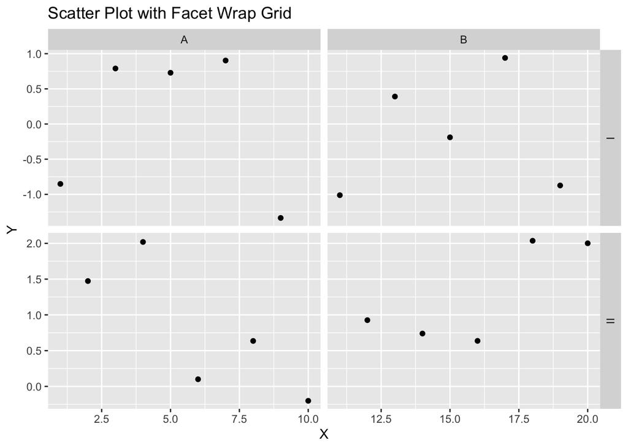

```r
cancellations <- flights %>%

  # just filter for destination == 'SFO'
  filter(dest == 'SFO') %>%

  # a cancelled flight is one with no `dep_time`
  filter(is.na(dep_time))


# Create example dataframe
df <- data.frame(
  x = 1:20,
  y = rnorm(20),
  group = rep(c("A", "B"), each = 10),
  category = rep(c("I", "II"), times = 10)
)

# Create scatter plot with facet wrap grid
ggplot(df, aes(x, y)) +
  geom_point() +
  facet_grid(category ~ group, scales = "free") +
  xlab("X") +
  ylab("Y") +
  ggtitle("Scatter Plot with Facet Wrap Grid")
```

I want you to think how we would organise our data manipulation to create the following plot. No need to write the code, just explain in words how you would go about it.

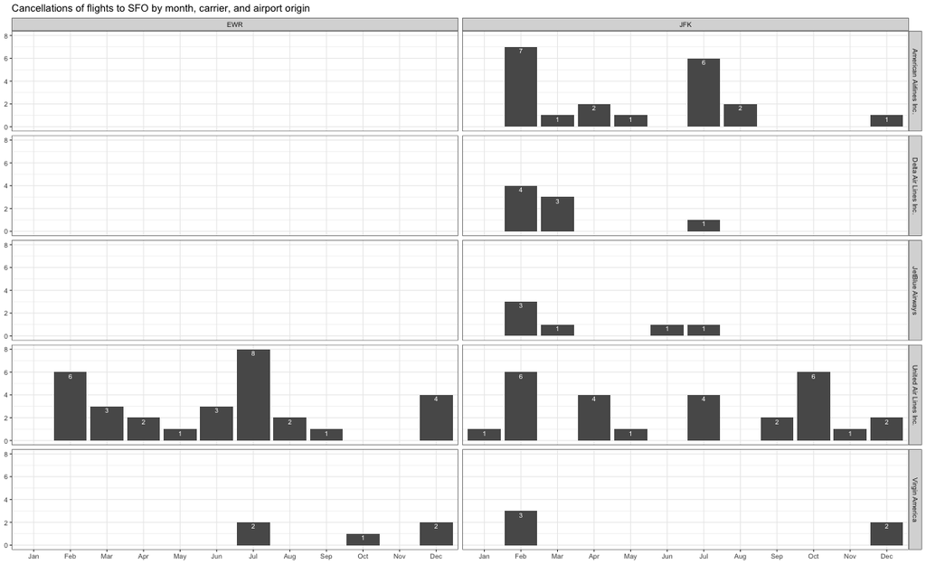

## Problem 10: On your own – Hollywood Age Gap

The website https://hollywoodagegap.com is a record of *THE AGE DIFFERENCE IN YEARS BETWEEN MOVIE LOVE INTERESTS*. This is an informational site showing the age gap between movie love interests and the data follows certain rules:

- The two (or more) actors play actual love interests (not just friends, coworkers, or some other non-romantic type of relationship)
- The youngest of the two actors is at least 17 years old
- No animated characters

The age gaps dataset includes “gender” columns, which always contain the values “man” or “woman”. These values appear to indicate how the characters in each film identify and some of these values do not match how the actor identifies. We apologize if any characters are misgendered in the data!

The following is a data dictionary of the variables used

| variable | class | description |
| --- | --- | --- |
| movie_name | character | Name of the film |
| release_year | integer | Release year |
| director | character | Director of the film |
| age_difference | integer | Age difference between the characters in whole years |
| couple_number | integer | An identifier for the couple in case multiple couples are listed for this film |
| actor_1_name | character | The name of the older actor in this couple |
| actor_2_name | character | The name of the younger actor in this couple |
| character_1_gender | character | The gender of the older character, as identified by the person who submitted the data for this couple |
| character_2_gender | character | The gender of the younger character, as identified by the person who submitted the data for this couple |
| actor_1_birthdate | date | The birthdate of the older member of the couple |
| actor_2_birthdate | date | The birthdate of the younger member of the couple |
| actor_1_age | integer | The age of the older actor when the film was released |
| actor_2_age | integer | The age of the younger actor when the film was released |

```r
age_gaps <- readr::read_csv('https://raw.githubusercontent.com/rfordatascience/tidytuesday/master/data/2023/2023-02-14/age_gaps.csv')
```

How would you explore this data set? Here are some ideas of tables/ graphs to help you with your analysis

- How is `age_difference` distributed? What’s the ‘typical’ `age_difference` in movies?
- The `half plus seven\` rule. Large age disparities in relationships carry certain stigmas. One popular rule of thumb is the [half-your-age-plus-seven](https://en.wikipedia.org/wiki/Age_disparity_in_sexual_relationships#The_.22half-your-age-plus-seven.22_rule) rule. This rule states you should never date anyone under half your age plus seven, establishing a minimum boundary on whom one can date. In order for a dating relationship to be acceptable under this rule, your partner’s age must be:

$$\frac{\text{Your age}}{2} + 7 < \text{Partner Age} < (\text{Your age} - 7) * 2$$
How frequently does this rule apply in this dataset?

- Which movie has the greatest number of love interests?
- Which actors/ actresses have the greatest number of love interests in this dataset?
- Is the mean/median age difference staying constant over the years (1935 - 2022)?
- How frequently does Hollywood depict same-gender love interests?

# Deliverables

There is a lot of explanatory text, comments, etc. You do not need these, so delete them and produce a stand-alone document that you could share with someone. Render the edited and completed Quarto Markdown (qmd) file as a Word document (use the “Render” button at the top of the script editor window) and upload it to Canvas. You must be commiting and pushing tour changes to your own Github repo as you go along.

# Details

**Please seek out help when you need it,** and remember the [15-minute rule](https://mam2022.netlify.app/syllabus/#the-15-minute-rule). You know enough R (and have enough examples of code from class and your readings) to be able to do this. If you get stuck, ask for help from others, post a question on Slack– and remember that I am here to help too!

> As a true test to yourself, do you understand the code you submitted and are you able to explain it to someone else?

# Rubric

13/13: Problem set is 100% completed. Every question was attempted and answered, and most answers are correct. Code is well-documented (both self-documented and with additional comments as necessary). Used tidyverse, instead of base R. Graphs and tables are properly labelled. Analysis is clear and easy to follow, either because graphs are labeled clearly or you’ve written additional text to describe how you interpret the output. Multiple Github commits. Work is exceptional. I will not assign these often.

8/13: Problem set is 60–80% complete and most answers are correct. This is the expected level of performance. Solid effort. Hits all the elements. No clear mistakes. Easy to follow (both the code and the output). A few Github commits.

5/13: Problem set is less than 60% complete and/or most answers are incorrect. This indicates that you need to improve next time. I will hopefully not assign these often. Displays minimal effort. Doesn’t complete all components. Code is poorly written and not documented. Uses the same type of plot for each graph, or doesn’t use plots appropriate for the variables being analyzed. No Github commits.